# EBASE overview

## Installation

This vignette provides an overview of the theory and use of the the Estuarine BAyesian Single-station Estimation (EBASE) R package for ecosystem metabolism. Use the following to install the package from R-Universe. The [JAGS](https://mcmc-jags.sourceforge.io/) software must also be installed to use this package. Follow the instructions in the link to download and install the JAGS version appropriate for your operating system.

```r
# Install EBASE in R:
install.packages('EBASE', repos = c('https://fawda123.r-universe.dev', 'https://cloud.r-project.org'))
```

Load the package after installation to use the functions.

```r
library(EBASE)
```

## Usage

An example file called `exdat()` is included with the package that demonstrates the required time series format to use the functions. It includes nearly a year of continuously monitored water quality and meteorological data at the Apalachicola National Estuarine Research Reserve. The required data include a date and time vector (`DateTimeStamp`), dissolved oxygen (mg L-1, `DO_obs`) , water temperature (C, `Temp`), salinity (psu, `Sal`), PAR (W m-2, `PAR`), and wind speed (m s-1, `WSpd`). The time step should be consistent throughout the dataset and is indicated as an argument to the `ebase()` function (see below). The `exdat()` dataset can be viewed at any time after the package is loaded and is used in the examples in the help files:

```r
head(exdat)
```

```
#>         DateTimeStamp DO_obs Temp  Sal PAR WSpd
#> 1 2012-02-23 00:00:00    8.8 16.4 23.0   0  3.6
#> 2 2012-02-23 00:15:00    8.8 16.4 22.8   0  3.5
#> 3 2012-02-23 00:30:00    8.8 16.4 22.7   0  3.6
#> 4 2012-02-23 00:45:00    8.8 16.4 22.9   0  4.2
#> 5 2012-02-23 01:00:00    8.7 16.4 22.7   0  3.6
#> 6 2012-02-23 01:15:00    8.5 16.4 23.4   0  4.1
```

The core function to estimate metabolism is `ebase()`. The metabolic estimates are based on a mass balance equation in Grace et al. (2015) with the gas exchange estimate from Wanninkhof (2014). It is similar to that provided by the BASEmetab R package at https://github.com/dgiling/BASEmetab, with modifications to estimate different parameters optimized by the JAGS model:

$$Z\frac{dC_d}{dt} = aPAR - R + bU_{10}^2\left(\frac{Sc}{600}
\right)^{-0.5} \left(C_{Sat} - C_d \right )$$

More simply:

$$Z\frac{dC_d}{dt} = P - R + D$$

Net ecosystem metabolism (NEM) is then estimated as:

$$NEM = P - R$$

The metabolic estimates are defined by the change in dissolved oxygen over the time step $\frac{dC_d}{dt}$, where gross production is provided by $aPAR$, respiration is provided by $R$, and gas exchange is provided by the remainder. Required inputs for the equation are dissolved oxygen concentration as $C_d$, solar radiation as $PAR$, water column depth as $Z$ (meters), and wind speed as $U$. Other inputs for the schmidt number $Sc$ and dissolved oxygen at saturation $C_{Sat}$ are calculated from the observed data. The remaining three parameters $a$, $R$, and $b$ are estimated by likelihood given the observed data with the JAGS model using prior distributions shown in the model file. At each time step, the change in oxygen concentration between time steps is calculated from the equation using model inputs and parameter guesses, and then a finite difference approximation is used to estimate modeled oxygen concentration. The first modeled value starts at the mean oxygen concentration for all measurements in the optimization period. The estimated concentration is also returned at each time step, which can be compared to observed as one measure of model performance.

The following shows how to use the `ebase()` function with a subset of four days from the `exdat()` example dataset. Running the model on the entire year will take a few minutes, so a subset is used:

```r
library(dplyr)
library(lubridate)

# subset four days in June
dat <- exdat %>%
  filter(month(exdat$DateTimeStamp) == 6 & day(exdat$DateTimeStamp) %in% 1:4)

head(dat)
```

```
#>         DateTimeStamp DO_obs Temp  Sal PAR WSpd
#> 1 2012-06-01 00:00:00    4.5 29.5 23.0   0  2.0
#> 2 2012-06-01 00:15:00    5.1 29.5 23.3   0  2.3
#> 3 2012-06-01 00:30:00    4.8 29.5 23.4   0  2.1
#> 4 2012-06-01 00:45:00    4.8 29.5 23.3   0  2.0
#> 5 2012-06-01 01:00:00    4.8 29.5 23.1   0  1.7
#> 6 2012-06-01 01:15:00    5.0 29.5 24.0   0  1.8
```

Also note that any “dangling” observations at the start or end of the time series that do not include an entire day are removed from the input data prior to estimating metabolism. A warning is returned if these observations are found and removed.

```r
res <- ebase(dat, interval = 900, Z = 1.85, n.chains = 2)
head(res)
```

```
#>         DateTimeStamp       Date grp    Z  DO_obs   DO_mod DO_modlo DO_modhi
#> 1 2012-06-01 00:00:00 2012-06-01   1 1.85 140.625 166.1132 166.1112 166.1152
#> 2 2012-06-01 00:15:00 2012-06-01   1 1.85 159.375 165.4135 165.1514 165.6797
#> 3 2012-06-01 00:30:00 2012-06-01   1 1.85 150.000 164.7458 164.2165 165.2784
#> 4 2012-06-01 00:45:00 2012-06-01   1 1.85 150.000 164.0582 163.2671 164.8557
#> 5 2012-06-01 01:00:00 2012-06-01   1 1.85 150.000 163.3622 162.3135 164.4221
#> 6 2012-06-01 01:15:00 2012-06-01   1 1.85 156.250 162.6401 161.3221 163.9645
#>         dDO converge       rsq        a       alo      ahi         b      blo
#> 1        NA     Fine 0.3316977       NA        NA       NA        NA       NA
#> 2 -67.17103     Fine 0.3316977 0.893719 0.5493333 1.237225 0.3099639 0.095399
#> 3 -64.09915     Fine 0.3316977 0.893719 0.5493333 1.237225 0.3099639 0.095399
#> 4 -66.01783     Fine 0.3316977 0.893719 0.5493333 1.237225 0.3099639 0.095399
#> 5 -66.81054     Fine 0.3316977 0.893719 0.5493333 1.237225 0.3099639 0.095399
#> 6 -69.32714     Fine 0.3316977 0.893719 0.5493333 1.237225 0.3099639 0.095399
#>         bhi  P Plo Phi        R      Rlo      Rhi       NEM     NEMlo     NEMhi
#> 1        NA NA  NA  NA       NA       NA       NA        NA        NA        NA
#> 2 0.4880948  0   0   0 141.3441 91.81687 189.3383 -141.3441 -189.3383 -91.81687
#> 3 0.4880948  0   0   0 141.3441 91.81687 189.3383 -141.3441 -189.3383 -91.81687
#> 4 0.4880948  0   0   0 141.3441 91.81687 189.3383 -141.3441 -189.3383 -91.81687
#> 5 0.4880948  0   0   0 141.3441 91.81687 189.3383 -141.3441 -189.3383 -91.81687
#> 6 0.4880948  0   0   0 141.3441 91.81687 189.3383 -141.3441 -189.3383 -91.81687
#>          D      Dlo      Dhi
#> 1       NA       NA       NA
#> 2 17.07768 5.256220 26.89167
#> 3 22.76066 7.016668 35.73653
#> 4 19.21110 5.935163 30.23677
#> 5 17.74459 5.472476 28.00036
#> 6 13.08888 4.054735 20.68587
```

The results are returned as a data frame with instantaneous metabolic estimates for areal gross production (O2 mmol m-2 d-1, `P` or $aPAR$ from above as volumetric), respiration (O2 mmol m-2 d-1, `R` from above as volumetric), and gas exchange (O2 mmol m-2 d-1, `D` or the remainder of the equation from above as volumetric, positive values as ingassing, negative values as outgassing). `NEM` (net ecosystem metabolism, O2 mmol m-2 d-1) is also returned as `P` - `R`. Additional parameters estimated by the model that are returned include `a` and `b` as shown in the above equation. The `a` parameter is a constant that represents the primary production per quantum of light with units of (mmol m-2 d-1)/(W m-2) and is used to estimate gross production (Grace et al. 2015). The `b` parameter is a constant used to estimate gas exchange in (cm hr-1)/(m2 s-2) (provided as 0.251 in eqn. 4 in Wanninkhof (2014)).

A plot of the results can be made with `ebase_plot()`.

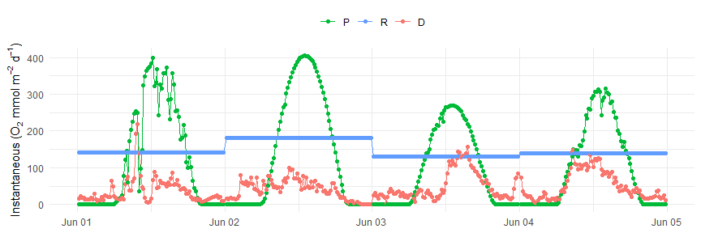

```r
ebase_plot(res)
```

The daily averages can also be plotted by using `instantaneous = FALSE`.

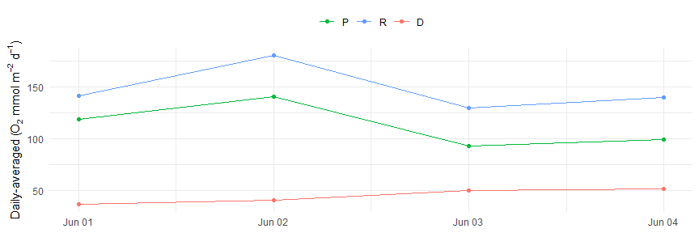

```r
ebase_plot(res, instantaneous = FALSE)
```

Similarly, a plot of net ecosystem metabolism (NEM) with production and respiration can be made with `ebase_plot()` using `asnem = T`. This plot shows NEM as the difference between production and respiration. Gas exchange is not shown and respiration is expressed negatively to show the negative contribution to NEM.

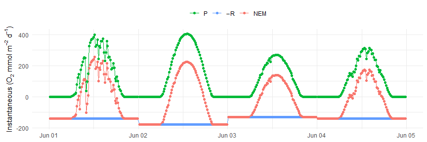

```r
ebase_plot(res, asnem = T)
```

Execution time of the model can also be reduced by using multiple processors. This is done using [doParrallel](https://cran.r-project.org/package=doParallel) package and registering a parallel backend as below.

```r
# setup parallel backend
library(doParallel)
cl <- makeCluster(2)
registerDoParallel(cl)

res <- ebase(dat, interval = 900, Z = 1.85, n.chains = 2)

stopCluster(cl)
```

Model fit can be assessed using the `converge` and `rsq` columns from the returned results. The values in these columns apply to each group in the `grp` column as specified with the `ndays` argument. The `converge` column indicates `"Check convergence"` or `"Fine"` if the JAGS estimate converged at that iteration (repeated across rows for the group). The `n.chains` argument can be increased if convergence is not achieved. Similarly, the `rsq` column shows the r-squared values of the linear fit between the modeled and observed dissolved oxygen (repeated across rows for the group).

The model fit can also be assessed by comparing the observed and modeled values for dissolved oxygen with the `fit_plot()` function. Estimated values are shown as line and observed values are shown as points.

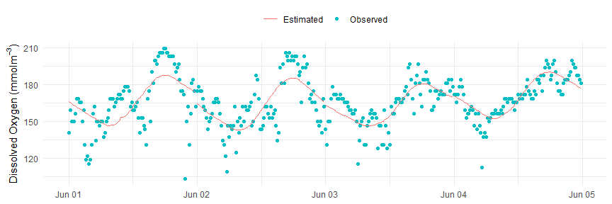

```r
fit_plot(res)
```

The comparison can also be separated by group with `bygroup = TRUE` based on the value for the `ndays` argument passed to `ebase()`. The r-squared value of the fit between modeled and observed dissolved oxygen is also shown in the facet label for the group.

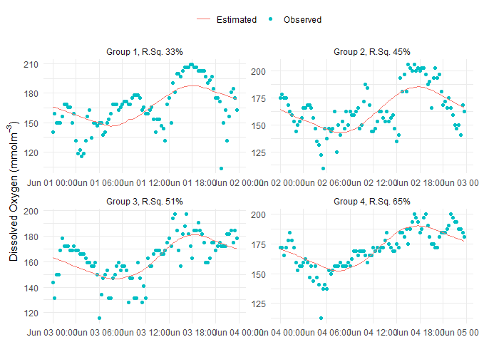

```r
fit_plot(res, bygroup = TRUE)
```

A scatterplot showing modeled versus observed dissolved oxygen can also be returned by setting `scatter = TRUE`.

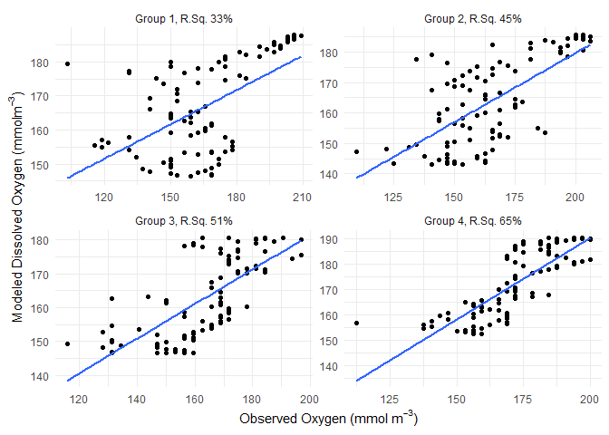

```r
fit_plot(res, bygroup = TRUE, scatter = TRUE)
```

The prior distributions for the $a$, $R$, and $b$ parameters are defined in the model file included with the package as normal Gaussian distributions with mean and standard deviations provided by the `aprior`, `rprior`, and `bprior` arguments in `ebase()`. The location of the model file can be viewed as follows.

```r
system.file('ebase_model.txt', package = 'EBASE')
```

The default values for the priors were chosen based on the ability of EBASE to reproduce known parameters from a forward metabolism model. An additional constraint is that all the prior distributions are truncated to be positive values as required by the core metabolism equation above. The upper limit for $b$ is also set as twice the default value of the mean in the `bprior` argument. Units for each parameter are (mmol m-2 d-1)/(W m-2) for $a$, mmol m-2 d-1 for $R$, and (cm hr-1)/(m2 s-2) for $b$.

The prior distributions can be viewed with the `prior_plot()` function. No changes are needed to the default arguments for this function if the default arguments are used for `ebase()`. The density curves are normalized such that the peak value is always equal to 1.

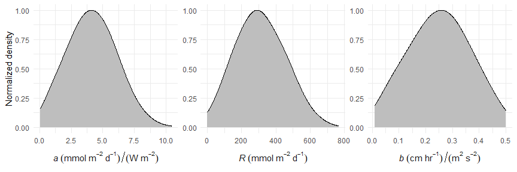

```r
prior_plot()
```

95% credible intervals for `a`, `R` (as areal), and `b` are also returned with the output from `ebase()` in the corresponding columns `alo`, `ahi`, `blo`, `bhi`, `Rlo`, and `Rhi`, for the 2.5th and 97.5th percentile estimates for each parameter, respectively. These values indicate the interval within which there is a 95% probability that the true parameter is in this range and is a representation of the posterior distributions for each parameter. Note that all values for these parameters are repeated across rows, although only one estimate for each is returned based on the number of days defined by `ndays`.

The credible intervals can be plotted with the `credible_plot()` function.

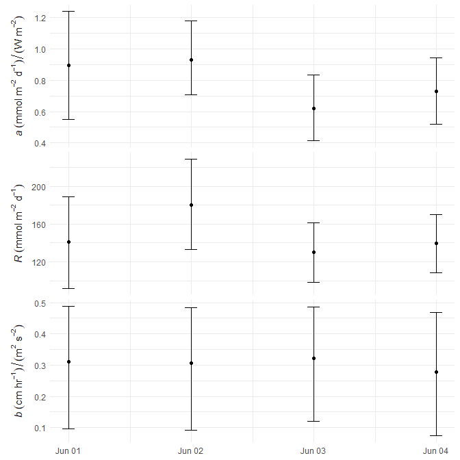

```r
credible_plot(res)
```

The credible intervals can also be retrieved as a data frame using `credible_prep()`. This function is provided as a convenience to parse the results from `ebase()`.

```r
credible_prep(res)
```

```
#> # A tibble: 12 × 6
#> # Groups:   grp [4]
#>    Date         grp var      mean       lo      hi
#>    <date>     <dbl> <fct>   <dbl>    <dbl>   <dbl>
#>  1 2012-06-01     1 a       0.894   0.549    1.24
#>  2 2012-06-01     1 R     141.     91.8    189.
#>  3 2012-06-01     1 b       0.310   0.0954   0.488
#>  4 2012-06-02     2 a       0.929   0.705    1.18
#>  5 2012-06-02     2 R     180.    133.     229.
#>  6 2012-06-02     2 b       0.307   0.0927   0.484
#>  7 2012-06-03     3 a       0.618   0.413    0.833
#>  8 2012-06-03     3 R     130.     97.9    161.
#>  9 2012-06-03     3 b       0.321   0.120    0.487
#> 10 2012-06-04     4 a       0.728   0.518    0.941
#> 11 2012-06-04     4 R     140.    108.     170.
#> 12 2012-06-04     4 b       0.279   0.0741   0.468
```

Finally, although `ebase()` can be used to estimate metabolism for time series with several years of data, the `ebase_years()` function can be used to estimate results sequentially for each year. This is useful because model estimation using `ebase_years()` will continue after a year fails, e.g., when some years have long periods of missing or erroneous data. This eliminates the need to restart the model or further pre-process the data. The same arguments for `ebase()` are used for `ebase_years()`. Progress is printed directly in the console and the user can specify the number of attempts for failed years before proceeding to the following year.

## Changing the default arguments

### Equation optimization length

The `ndays` argument in `ebase()` defines the model optimization period as the number of days that are used for optimizing the above mass balance equation. By default, this is done each day, i.e., `ndays = 1` such that a loop is used that applies the model equation to observations within each day, evaluated iteratively from the first observation in a day to the last. Individual parameter estimates for `a`, `R`, and `b` are then returned for each day. However, more days can be used to estimate the unknown parameters, such that the loop can be evaluated for every `ndays` specified by the argument. The `ndays` argument will separate the input data into groups of consecutive days, where each group has a total number of days equal to `ndays`. The final block may not include the complete number of days specified by `ndays` if the number of unique dates in the input data includes a remainder when divided by `ndays`, e.g., if seven days are in the input data and `ndays = 5`, there will be two groups where the first has five days and the second has two days. The output data from `ebase` includes a column that specifies the grouping that was used based on `ndays`.

Here, the number of days used to optimize the equation is set to all days in the input data.

```r
cl <- makeCluster(2)
registerDoParallel(cl)

res <- ebase(dat, interval = 900, Z = 1.85, n.chains = 2, ndays = 4)

stopCluster(cl)
```

And the resulting plot:

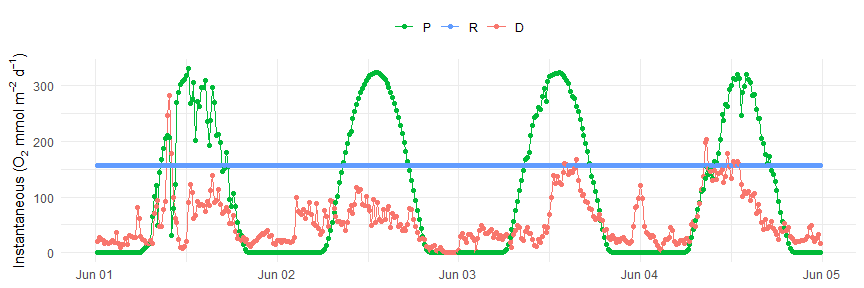

```r
ebase_plot(res, instantaneous = TRUE)
```

And the fit of observed and modeled dissolved oxygen (note the unbroken line for all days estimated together):

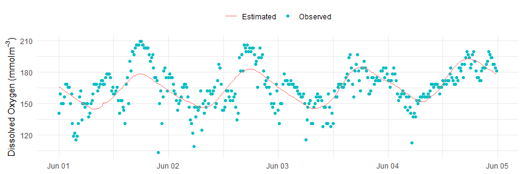

```r
fit_plot(res)
```

### Starting value

The `doave` argument can be used to define which dissolved oxygen value is used as the starting point in the Bayesian estimation for the optimization period. The default setting (`doave = TRUE`) will use the average of all the dissolved oxygen values in the optimization period defined by `ndays`. For example, the average of all dissolved oxygen values in each 24 hour period will be used if `doave = TRUE` and `ndays = 1`. The first dissolved oxygen observation of the time series in the optimization period will be used as the starting point if `doave = F`. In this case, the simulated dissolved oxygen time series will always start at the first observed dissolved oxygen value for each optimization period.

The default setting uses the average observed dissolved oxygen in each optimization period as the starting value. Below, `doave = FALSE` is used to set the first observed dissolved oxygen as the starting value.

```r
cl <- makeCluster(2)
registerDoParallel(cl)

res <- ebase(dat, interval = 900, Z = 1.85, n.chains = 2, ndays = 1, doave = F)

stopCluster(cl)
```

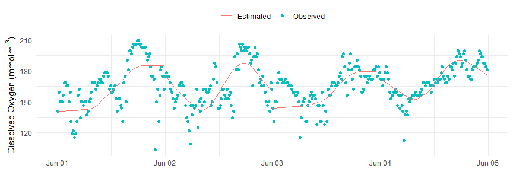

```r
fit_plot(res)
```

### Missing values

Missing values in the input data for the specified time step in the `interval` argument to `ebase()` must be interpolated prior to estimating metabolism. It is the responsibility of the user to verify that these interpolated values are not wildly inaccurate. Missing values are linearly interpolated between non-missing values at the time step specified by the value in `interval`. This works well for small gaps, but can easily create inaccurate values at gaps larger than a few hours.

As an example, the `dat` object above is subset to 90% of its observations.

```r
set.seed(222)
dat2 <- dat %>%
  slice_sample(prop = 0.9) %>%
  arrange(DateTimeStamp)
head(dat2)
```

```
#>         DateTimeStamp DO_obs Temp  Sal PAR WSpd
#> 1 2012-06-01 00:00:00    4.5 29.5 23.0   0  2.0
#> 2 2012-06-01 00:30:00    4.8 29.5 23.4   0  2.1
#> 3 2012-06-01 01:00:00    4.8 29.5 23.1   0  1.7
#> 4 2012-06-01 01:30:00    5.4 29.6 24.9   0  1.8
#> 5 2012-06-01 01:45:00    5.4 29.6 24.6   0  1.8
#> 6 2012-06-01 02:00:00    5.3 29.6 24.8   0  2.0
```

The `ebase_prep()` function is used internally to `ebase` to prepare the data for the metabolism calculations. This function interpolates the missing data and returns a column `isinterp` that specifies `TRUE` or `FALSE` if a value is interpolated.

```r
dat2interp <- ebase_prep(dat2, Z = 1.85, interval = 900)
head(dat2interp)
```

```
#>         Date       DateTimeStamp isinterp  DO_obs   DO_sat    Z Temp  Sal PAR
#> 1 2012-06-02 2012-06-02 00:00:00    FALSE 175.000 213.4922 1.85 28.8 21.8   0
#> 2 2012-06-02 2012-06-02 00:15:00    FALSE 178.125 212.6648 1.85 28.8 22.5   0
#> 3 2012-06-02 2012-06-02 00:30:00    FALSE 175.000 211.7234 1.85 28.9 23.0   0
#> 4 2012-06-02 2012-06-02 00:45:00    FALSE 175.000 212.3111 1.85 28.9 22.5   0
#> 5 2012-06-02 2012-06-02 01:00:00    FALSE 168.750 212.1933 1.85 29.0 22.3   0
#> 6 2012-06-02 2012-06-02 01:15:00    FALSE 162.500 211.7237 1.85 29.0 22.7   0
#>   WSpd       sc grp
#> 1  1.9 355.5996   1
#> 2  1.8 356.3840   1
#> 3  1.9 355.2102   1
#> 4  1.9 354.6523   1
#> 5  1.8 352.7068   1
#> 6  1.8 353.1511   1
```

The interpolated values can be visually inspected using the `interp_plot()` function.

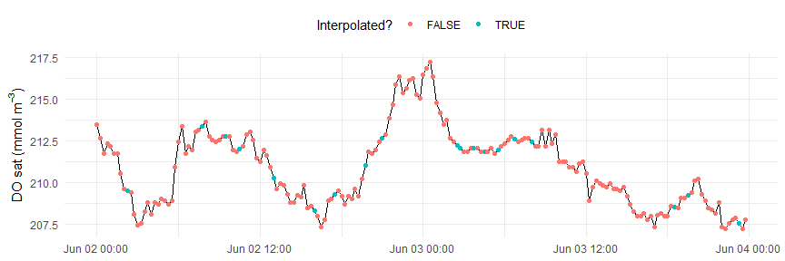

```r
interp_plot(dat2, Z = 1.85, interval = 900, param = 'DO_sat')
```

The `ebase()` function includes the `maxinterp` argument to assign `NA` values to continuously interpolated rows with length greater than the value defined by `maxinterp`. This value is set to 12 hours by default and applies to the groupings defined by `ndays`, i.e., any group with a continuous set of interpolated values where the time is greater than 12 hours are assigned `NA` (except `Date` and `DateTimeStamp`). The numeric value passed to `maxinterp` is the number of time steps for the input data, e.g., 48 would be 12 hours if the time step is 900 seconds.

### Changing priors

If the default values prior distributions are changed for `ebase()`, the `prior_plot()` function can be used to assess how changing characteristics of the prior distributions could influence the resulting parameter estimates and their posterior distributions (e.g., as shown with `credible_plot()`).

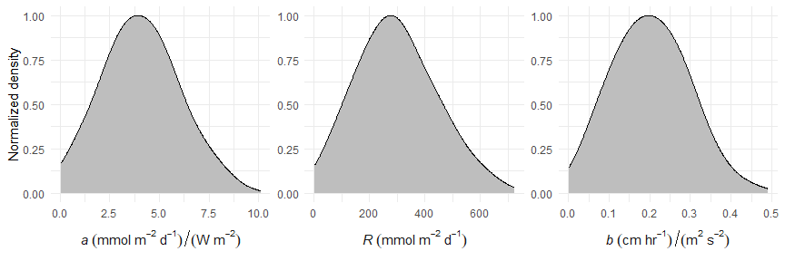

```r
prior_plot(bprior = c(0.2, 0.1))
```

The same change to the prior distribution for the $b$ parameter is applied to `ebase()`

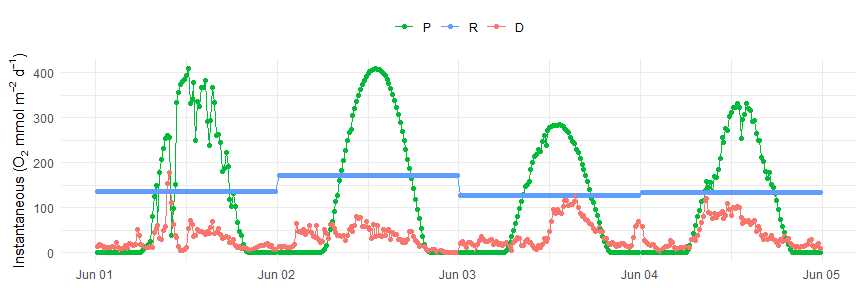

```r
cl <- makeCluster(2)
registerDoParallel(cl)

res <- ebase(dat, interval = 900, Z = 1.85, n.chains = 2, bprior = c(0.2, 0.1))

stopCluster(cl)

ebase_plot(res, instantaneous = TRUE)
```

The `credible_plot()` function can be used to assess how changing the prior distributions has an influence on the posterior distributions of the parameters.

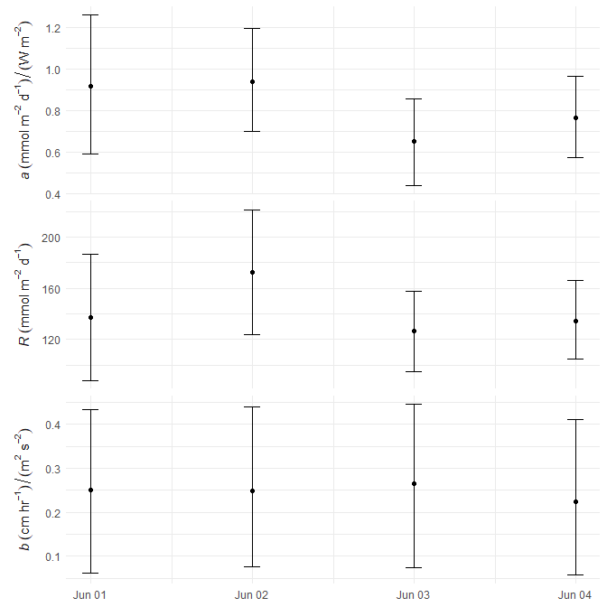

```r
credible_plot(res)
```

# References

Grace, Michael R, Darren P Giling, Sally Hladyz, Valerie Caron, Ross M Thompson, and Ralph Mac Nally. 2015. “Fast Processing of Diel Oxygen Curves: Estimating Stream Metabolism with BASE (BA Yesian s Ingle-Station e Stimation).” *Limnology and Oceanography: Methods* 13 (3): 103–14. https://doi.org/10.1002/lom3.10011.

Wanninkhof, Rik. 2014. “Relationship Between Wind Speed and Gas Exchange over the Ocean Revisited.” *Limnology and Oceanography: Methods* 12 (6): 351–62. https://doi.org/10.4319/lom.2014.12.351.